# R Notebook

# plot

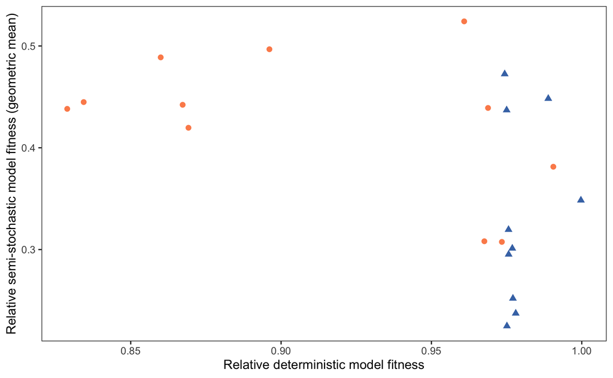

#————Correlation of cue variation on fitness decline————–# # import data

| time | variable | value | cue | log | iter |
| --- | --- | --- | --- | --- | --- |
| 0.0 | R | 8.890000e+06 | I | log10 | 1 |
| 0.0 | M | 0.000000e+00 | I | log10 | 1 |
| 0.0 | Mg | 0.000000e+00 | I | log10 | 1 |
| 0.0 | ID | 0.000000e+00 | I | log10 | 1 |
| 0.0 | I | 0.000000e+00 | I | log10 | 1 |
| 0.0 | Ig | 0.000000e+00 | I | log10 | 1 |
| 0.0 | G | 0.000000e+00 | I | log10 | 1 |
| 0.0 | N | 0.000000e+00 | I | log10 | 1 |
| 0.0 | W | 0.000000e+00 | I | log10 | 1 |
| 0.0 | cr_t | 0.000000e+00 | I | log10 | 1 |

[output cut: 990 more lines]

# filter data to keep only cues

| time | iter | R | I | cr |
| --- | --- | --- | --- | --- |
| 0.0 | 1 | 6.948902 | -Inf | NA |
| 0.1 | 1 | 6.948901 | 1.724824 | 0.000000e+00 |
| 0.2 | 1 | 6.948899 | 1.802635 | 0.000000e+00 |
| 0.3 | 1 | 6.948898 | 1.868292 | 0.000000e+00 |
| 0.4 | 1 | 6.948897 | 1.925045 | 0.000000e+00 |
| 0.5 | 1 | 6.948895 | 1.974991 | 0.000000e+00 |
| 0.6 | 1 | 6.948893 | 2.019566 | 0.000000e+00 |
| 0.7 | 1 | 6.948892 | 2.059793 | 0.000000e+00 |
| 0.8 | 1 | 6.948890 | 2.096429 | 0.000000e+00 |
| 0.9 | 1 | 6.948888 | 2.130048 | 0.000000e+00 |

[output cut: 990 more lines]

# plot variation of cue over time

|  | cue_range | cr | id |
| --- | --- | --- | --- |
| 2.5000 | 6000000.0 | 0.000000e+00 | I_log |
| 2.4999 | 5981296.7 | 0.000000e+00 | I_log |
| 2.4998 | 5962651.8 | 0.000000e+00 | I_log |
| 2.4997 | 5944064.9 | 0.000000e+00 | I_log |
| 2.4996 | 5925536.0 | 0.000000e+00 | I_log |
| 2.4995 | 5907064.9 | 0.000000e+00 | I_log |
| 2.4994 | 5888651.3 | 0.000000e+00 | I_log |
| 2.4993 | 5870295.2 | 0.000000e+00 | I_log |
| 2.4992 | 5851996.2 | 0.000000e+00 | I_log |
| 2.4991 | 5833754.3 | 0.000000e+00 | I_log |

[output cut: 990 more lines]

```r
# plot together
mc_cue.pl <- ggarrange(mc_ilog_cue.pl, mc_ilog_cue.pl2, mc_ilog_cr.pl,  mc_rlog_ilog_cr.pl, common.legend = T, ncol = 2, nrow = 2, align = "hv")
```

[output not shown]

#———— Impact of individual parameter variation on fitness ————# ## combine all single parameter variation files

| X | iter | rho | burst | iota_N1 | iota_N2 | phi_N1 | phi_N2 | fitness_rho | fitness_beta | fitness_psin | fitness_psiw | fitness_phin | fitness_phiw | id |
| --- | --- | --- | --- | --- | --- | --- | --- | --- | --- | --- | --- | --- | --- | --- |
| 1 | 1 | 0.2627156 | 5.721 | 16.69234 | 0.8431785 | 0.03520591 | 550.842 | 9.563397 | 9.563397 | 9.563397 | 9.563397 | 9.563397 | 9.563397 | G_log |
| 1 | 1 | 0.2627156 | 5.721 | 16.69234 | 0.8431785 | 0.03520591 | 550.842 | 9.666520 | 9.666520 | 9.666520 | 9.666520 | 9.666520 | 9.666520 | G_log-I_log |
| 1 | 1 | 0.2627156 | 5.721 | 16.69234 | 0.8431785 | 0.03520591 | 550.842 | 9.630221 | 9.630221 | 9.630221 | 9.630221 | 9.630221 | 9.630221 | G_log-I+Ig_log |
| 1 | 1 | 0.2627156 | 5.721 | 16.69234 | 0.8431785 | 0.03520591 | 550.842 | 9.657323 | 9.657323 | 9.657323 | 9.657323 | 9.657323 | 9.657323 | G_log-Ig_log |
| 1 | 1 | 0.2627156 | 5.721 | 16.69234 | 0.8431785 | 0.03520591 | 550.842 | 9.637572 | 9.637572 | 9.637572 | 9.637572 | 9.637572 | 9.637572 | G_log-R_log |
| 1 | 1 | 0.2627156 | 5.721 | 16.69234 | 0.8431785 | 0.03520591 | 550.842 | 8.590833 | 8.590833 | 8.590833 | 8.590833 | 8.590833 | 8.590833 | G_none |
| 1 | 1 | 0.2627156 | 5.721 | 16.69234 | 0.8431785 | 0.03520591 | 550.842 | 9.497079 | 9.497079 | 9.497079 | 9.497079 | 9.497079 | 9.497079 | I_log |
| 1 | 1 | 0.2627156 | 5.721 | 16.69234 | 0.8431785 | 0.03520591 | 550.842 | 8.499625 | 8.499625 | 8.499625 | 8.499625 | 8.499625 | 8.499625 | I_none |
| 1 | 1 | 0.2627156 | 5.721 | 16.69234 | 0.8431785 | 0.03520591 | 550.842 | 9.575495 | 9.575495 | 9.575495 | 9.575495 | 9.575495 | 9.575495 | I+Ig_log |
| 1 | 1 | 0.2627156 | 5.721 | 16.69234 | 0.8431785 | 0.03520591 | 550.842 | 9.636691 | 9.636691 | 9.636691 | 9.636691 | 9.636691 | 9.636691 | I+Ig_log-I_log |

[output cut: 10 more lines]

## process data for plotting

```r
c(mc_all_fitness_ref.df %>% arrange(desc(fitness_norm)) %>% select(short_label))$short_label
```

```
 [1] "R log & I log"        "R log & Total I log"  "G log & I log"        "G log & Ig log"       "R log & Ig log"       "Ig log & I log"
 [7] "Total I log & Ig log" "G log & R log"        "Total I log & I log"  "G log & Total I log"  "Ig log"               "Total I log"
[13] "G log"                "I log"                "Total I"              "G"                    "Ig"                   "I"
[19] "R"                    "R log"
```

# plotting 89% credible interval. By visual inspection of the distribution, ci represented the distribution (more honestly) than quantile, even when quantile seems to display larger differences of logging cues.

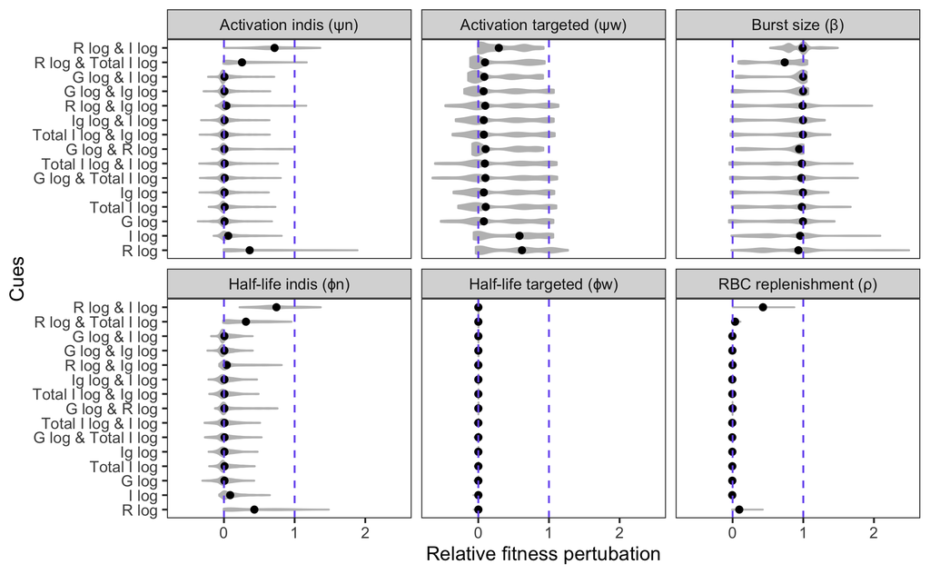

#——— arrange plots together ———#

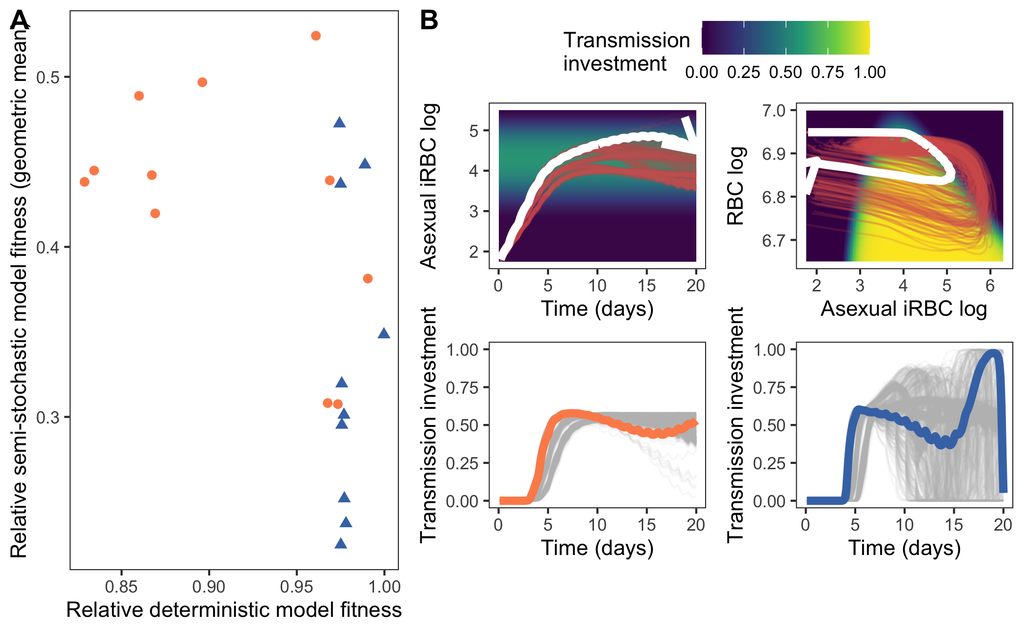

#==========================================# # Supplementary figure on MC posterior parameter distribution #==========================================# ## Process data

```r
## make into long format
posterior.long <- posterior.df %>%
  filter(iter %in% seq(0,1000,1)) %>%
  tidyr::pivot_longer(-iter, names_to = "parameter") %>%
  left_join(par_det.df, by = "parameter") %>% ## add in the deterministic parameter values
  mutate(label = case_when(
    parameter_label = case_when( ## recode parameter values
    parameter == "rho" ~ "RBC replenishment (ρ)",
    parameter == "phin" ~ "Half-life indis (ϕn)",
    parameter == "phiw" ~ "Half-life targeted (ϕw)",
    parameter == "psin" ~ "Activation indis (ψn)",
    parameter == "psiw" ~ "Activation targeted (ψw)",
    parameter == "beta" ~ "Burst size (β)"
  ))) ## rename paramter values
```

```
Error in is.data.frame(y) : object 'par_det.df' not found
```

## plot

```r
## portion of parameter values that does not need log-transforming
posterior_1.pl <- ggplot(posterior.long %>% filter(!parameter %in% c("phi_N1", "phi_N2", "iota_N1"))) +
  geom_density(aes(x = value), fill = "grey") +
  geom_vline(aes(xintercept = deterministic), linetype = "dashed") +
  facet_wrap(~label, scales = "free") +
  labs(x = "", y = "Density") +
  theme_bw() +
  theme(panel.grid.major = element_blank(),
        panel.grid.minor = element_blank())

## Plots where the x-axis should be log-transformed so it is easier to read
posterior_2.pl <- ggplot(posterior.long %>% filter(parameter %in% c("phi_N1", "phi_N2", "iota_N1"))) +
  geom_density(aes(x = value), fill = "grey") +
  geom_vline(aes(xintercept = deterministic), linetype = "dashed") +
  facet_wrap(~label, scales = "free") +
  labs(x = "Value", y = "Density") +
  scale_x_continuous(trans = "log10") +
  theme_bw() +
  theme(panel.grid.major = element_blank(),
        panel.grid.minor = element_blank())

## plot together
ggarrange(posterior_1.pl, posterior_2.pl, ncol = 1, align = "hv")

## save
ggsave(units = "px", dpi = 300, width = 2000, height = 1300, filename = here("code_repository/figures/posterior.tiff"), bg = "white", scale = 1)
```

[output not shown]

#==========================================# # Rank plot of parasite fitness with only one parameter varying #==========================================# ## process data for plotting

```r
## calculate geometric mean fitness for each parameter variation set
mc_single_fitness.sum2 <- mc_single_fitness.long %>%
  filter(str_detect(id, "log")) %>%
  mutate(fitness_norm = value/9.883602,
         fitness_ref_norm = fitness_ref/9.883602,
         cue_type = ifelse(str_detect(short_label, "&"), "Dual cue", "Single cue"),
   parameter_label = case_when( ## recode parameter values
    parameter == "rho" ~ "RBC replenishment (ρ)",
    parameter == "phin" ~ "Half-life indis (ϕn)",
    parameter == "phiw" ~ "Half-life targeted (ϕw)",
    parameter == "psin" ~ "Activation indis (ψn)",
    parameter == "psiw" ~ "Activation targeted (ψw)",
    parameter == "beta" ~ "Burst size (β)"
  )) %>%
  group_by(short_label, parameter_label, fitness_ref_norm, cue_type) %>%
  summarise(geom_mean = exp(mean(log(fitness_norm))))
```

# plot

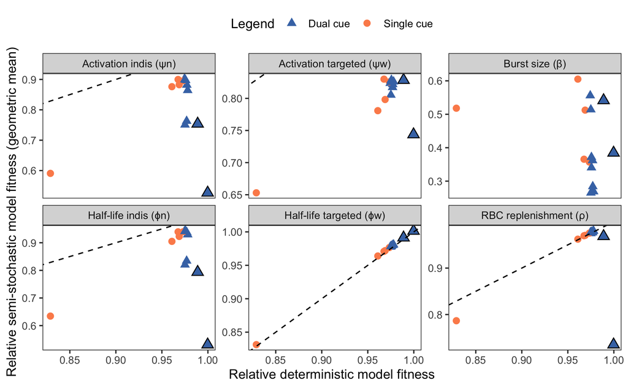

#==================================# # Understanding the mechanism behind robustness #==================================# #——–Calculating deviations between cr and fitness———-# # Process single parameter dynamics data

```r
# get list of files
mc_single_dyn.ls <- list.files(here("code_repository/data/mc_single_dyn"), pattern = "*.parquet", full.names = T)

# read in all of the files, filtering only for conversion rate
mc_single_dyn_cr.ls <- mclapply(mc_single_dyn.ls, function(x){
  df <- read_parquet(x)

  ## filter to retain only cr
  df_f <- df %>% filter(variable == "cr")
  return(df_f)
}, mc.cores = 6)

# combine
mc_single_dyn_cr.df <- do.call(rbind, mc_single_dyn_cr.ls)

# write
write_parquet(mc_single_dyn_cr.df, here("code_repository/data/mc_single_dyn_cr.parquet"))
mc_single_dyn_cr.df <- read_parquet(here("code_repository/data/mc_single_dyn_cr.parquet"))

# check # of records
mc_single_dyn_cr.df %>% group_by(id) %>% tally()
```

# Process deterministic conversion rate time series dynamic

```r
# single cue dynamics (conversion rate only)
si_cr.df <- si_dyn.df %>%
  filter(variable == "cr") %>%  ## get corresponding time steps (0.01) and cr only
  select(id, time, cr_det = value)

# dual cue dynamics (conversion rate only)
dual_cr.df <- dual_cue_dyn.df %>%
  filter(variable == "cr") %>%
  mutate(id = paste0(id, "-", id_b)) %>%
  select(id, time, cr_det = value)
```

# Calculate deviation in cr

```r
# left join
mc_single_dyn_cr_join.df <- mc_single_dyn_cr.df %>%
  left_join(rbind(
    si_cr.df, dual_cr.df
  ), by = c("time", "id"))

# get absoluate deviation
mc_single_dyn_cr_join.df_p <- mc_single_dyn_cr_join.df %>%
  filter(time != 0) %>% ## get rid of time = 0 wher cr is NA
  mutate(diff = abs(cr_det-value)) ## calculate absolute deviation
write_parquet(mc_single_dyn_cr_join.df_p, here("code_repository/data/mc_single_dyn_cr_join.parquet"))
mc_single_dyn_cr_join.df_p <- read_parquet(here("code_repository/data/mc_single_dyn_cr_join.parquet"))

# check for NAs
mc_single_dyn_cr_join.df_p %>% filter(is.na(diff))

# check # of samples
mc_single_dyn_cr_join.df_p %>% group_by(id, parameter) %>% tally()

# calculate summary statistics
mc_single_dyn_cr.sum <- mc_single_dyn_cr_join.df_p %>%
  ungroup() %>%
  group_by(id, parameter) %>%
  summarise(mean_cr_diff = mean(diff),
            median_cr_diff = median(diff),
            sd_cr_diff = sd(diff),
            mad_cr_diff= mad(diff))

write.csv(mc_single_dyn_cr.sum, here("code_repository/data/mc_single_dyn_cr_sum.csv"))
mc_single_dyn_cr.sum <- read.csv(here("code_repository/data/mc_single_dyn_cr_sum.csv"))
```

# calculate loss of fitness due to variation

```r
mc_single_dyn_cr.sum_fitness <- mc_single_fitness.sum2 %>%
  mutate(geo_mean_diff = geo_mean-fitness_det_norm) %>%
  left_join(mc_single_dyn_cr.sum, by = c("id", "parameter"))
```

# isolate examples of robust and non-robust cues

```r
## robust cue (I log)
mc_single_dyn_cr_join.df_p_robust <- mc_single_dyn_cr_join.df_p %>%
  filter(id == "I_log" & parameter %in% c("beta", "psin") & row_number() %% 10 == 0) %>%
  mutate(parameter_label = case_when(
    parameter == "psin" ~ "Activation indis (ψn)",
    parameter == "beta" ~ "Burst size (β)"
  ))

## non-robust cue (R and I+Ig log)
mc_single_dyn_cr_join.df_p_notrobust <- mc_single_dyn_cr_join.df_p %>%
  filter(id == "R_none-I+Ig_log" & parameter %in% c("beta", "psin") & row_number() %% 10 == 0) %>%
  mutate(parameter_label = case_when(
    parameter == "psin" ~ "Activation indis (ψn)",
    parameter == "beta" ~ "Burst size (β)"
  ))
```

# plot cr time series

```r
mc_single_cr_dyn.plt1 <- ggplot(mc_single_dyn_cr_join.df_p_robust) +
  geom_line(aes(x = time, y = value, group = iter), alpha = 0.01) +
  geom_line(aes(x = time, y = cr_det, group = iter), alpha = 1, color = "#785EF0") +
  facet_wrap(~parameter_label) +
  ylim(0, 1) +
  labs(x = "", y = "Conversion rate") +
  theme_bw() +
  theme(panel.grid.major = element_blank(),
        panel.grid.minor = element_blank(),
        axis.title.x = element_blank())

mc_single_cr_dyn.plt2 <- ggplot(mc_single_dyn_cr_join.df_p_notrobust) +
  geom_line(aes(x = time, y = value, group = iter), alpha = 0.01) +
  geom_line(aes(x = time, y = cr_det, group = iter), alpha = 1, color = "#785EF0") +
  facet_wrap(~parameter_label) +
  ylim(0, 1) +
  labs(x = "Time (days)", y = "Conversion rate") +
  theme_bw() +
  theme(panel.grid.major = element_blank(),
        panel.grid.minor = element_blank())
```

# plot relationship

```r
# relationship between fitness vs robistness
ggplot(mc_single_dyn_cr.sum_fitness, aes(x = fitness_det_norm, y = geo_mean_diff, color = fitness_det_norm)) +
  geom_point(size = 2.5, color = "black", shape = 1) +
  geom_point(size = 2, alpha=0.8) +
  facet_wrap(~parameter_label, scales = "free") +
  scale_color_viridis_c() +
  labs(x = "Deterministic model fitness", y = "Normalized fitness difference\n(Single-Deterministic)", color = "Deterministic\nmodel fitness") +
  theme_bw() +
  theme(panel.grid.major = element_blank(),
        panel.grid.minor = element_blank())

# relationship between conversion rate difference and difference in fitness
ggplot(mc_single_dyn_cr.sum_fitness, aes(x = median_cr_diff, geo_mean_diff, color = fitness_det_norm)) +
  geom_point(size = 2.5, color = "black", shape = 1) +
  geom_point(size = 2, alpha=0.8) +
  facet_wrap(~parameter_label) +
  scale_color_viridis_c() +
  ylim(NA, 0.02) +
  labs(x = "Median conversion rate difference", y = "Normalized fitness difference\n(Single-Deterministic)", color = "Deterministic\nmodel fitness") +
  theme_bw() +
  theme(panel.grid.major = element_blank(),
        panel.grid.minor = element_blank(),
        legend.position = "bottom")
mc_single_dyn_cr.sum_fitness
ggsave(here("code_repository/figures/mc_single_cr_rel_int.tiff"), units = "px", dpi = 300, width = 2550, height = 1200, bg = "white", scale = 1)

# internal code to get positions of I log and R and I+Ig log
ggplot(mc_single_dyn_cr.sum_fitness, aes(x = median_cr_diff, geo_mean_diff, color = fitness_det_norm)) +
  geom_point(size = 2.5, color = "black", shape = 1) +
  geom_point(size = 2, alpha=0.8) +
  geom_text(data = mc_single_dyn_cr.sum_fitness %>% filter(id %in% c("I_log", "R_none-I+Ig_log")), aes(x = median_cr_diff, y =geo_mean_diff, label = id)) +
  facet_wrap(~parameter_label) +
  scale_color_viridis_c() +
  ylim(NA, 0.02) +
  labs(x = "Median conversion rate difference", y = "Normalized fitness difference\n(Single-Deterministic)", color = "Deterministic\nmodel fitness") +
  theme_bw() +
  theme(panel.grid.major = element_blank(),
        panel.grid.minor = element_blank(),
        legend.position = "bottom")
```

[output not shown]

# plot together

```r
# conversion rate dynamic
ggarrange(mc_single_cr_dyn.plt1, mc_single_cr_dyn.plt2, nrow = 2, align = "v", labels = c("B", "C"))
ggsave(here("code_repository/figures/mc_single_cr_dyn_int.tiff"), units = "px", dpi = 300, width = 2550*(2/3), height = 1000, bg = "white", scale = 1)
```

[output not shown]

#=====================================# # Impact of cue perception on virulence #====================================# #——— Simulate dual cue data ———# # rerunning dual cue simulations to match single cue time step

|  | time | variable | value | id | id_b |
| --- | --- | --- | --- | --- | --- |
| 1.1 | 0.00 | R | 8890000 | G_log | I_log |
| 1.2 | 0.01 | R | 8889999 | G_log | I_log |
| 1.3 | 0.02 | R | 8889998 | G_log | I_log |
| 1.4 | 0.03 | R | 8889996 | G_log | I_log |
| 1.5 | 0.04 | R | 8889994 | G_log | I_log |
| 1.6 | 0.05 | R | 8889991 | G_log | I_log |
| 1.7 | 0.06 | R | 8889989 | G_log | I_log |
| 1.8 | 0.07 | R | 8889987 | G_log | I_log |
| 1.9 | 0.08 | R | 8889984 | G_log | I_log |
| 1.10 | 0.09 | R | 8889982 | G_log | I_log |

[output cut: 990 more lines]

#——— Divid dynamics data into high and low performing —————# # Single cue

```r
# classify top 2 performing single cues as "high performing"
top_2_single_cue <- si_opt.df %>%
  filter(cue != "t") %>%
  slice_max(n = 2, order_by = fitness_20) %>%
  mutate(short_label = gsub("I\\+Ig", "Total I", short_label))

# get wide format dataframe. Here, we are interested in the RBC and total iRBC count
si_dc.df <- si_dyn_30.df %>%
  mutate(value = as.numeric(value)) %>%
  filter(variable == "I" | variable == "Ig" | variable == "R") %>%
  tidyr::pivot_wider(names_from = variable, values_from = value) %>%
  mutate(total = I+Ig)

# split into top and poor-performing cues
si_dc.high <- si_dc.df %>% filter(id %in% top_2_single_cue$id)

# join high performing with label
si_dc.high <- si_dc.high %>% left_join(ez_label %>% distinct(id, .keep_all = T), by = "id")

# reorder cues by descending fitness
si_dc.high$short_label <- factor(si_dc.high$short_label, top_2_single_cue$short_label)
# classify top 2 performing single cues as "high performing"
top_2_single_cue <- si_opt.df %>%
  filter(cue != "t") %>%
  slice_max(n = 2, order_by = fitness_20) %>%
  mutate(short_label = gsub("I\\+Ig", "Total I", short_label))
```